# **K-Means Clustering to Get Player Recommendation**

# **Objective:**

OnSports is a fantasy sports platform that has fantasy leagues for many different sports and has witnessed an increasing number of participants globally over the past 5 years. For each player, a price is set at the start, and the price keeps changing over time based on the performance of the players in the real world. With the new English Premier League season about to start, they have collected data from the past season and want to analyze it to determine the price of each player for the start of the new season. OnSports have hired you as a data scientist and asked you to conduct a cluster analysis to identify players of different potentials of each player based on previous season performance. This will help them understand the patterns in player performances and fantasy returns and decide the exact price to be set for each player for the upcoming football season.

# **Data Variables:**

- **Player_Name:** Name of the player.
- **Club:** Club in which the player plays.
- **Position:** Position in which the player plays.
- **Goals_Scored:** Number of goals scored by the player in the previous season.
- **Assists:** Number of passes made by the player leading to goals in the previous season.
- **Total_Points:** Total number of fantasy points scored by the player in the previous season.
- **Minutes:** Number of minutes played by the player in the previous season.
- **Goals_Conceded:** Number of goals conceded by the player in the previous season.
- **Creativity:** A score, computed using a range of stats, that assesses player performance in terms of producing goalscoring opportunities for other players.
- **Influence:** A score, computed using a range of stats, that evaluates a player's impact on a match, taking into account actions that could directly or indirectly affect the match outcome.
- **Threat:** A score, computed using a range of stats, that gauges players who are most likely to score goals.
- **Bonus:** Total bonus points received. The three best performing players in each match receive additional bonus points based on a score computed using a range of stats. 3 points are awarded to the highest scoring player, 2 to the second best, and 1 to the third.
- **Clean_Sheets:** Number of matches without conceding a goal in the previous season.

# **Importing Libraries and Dataset Overview**

```python
!pip install scikit-learn-extra==0.3.0
!pip install numpy==1.25.0
```

[output not shown]

```python
# Read and manipulating data libraries
import numpy as np
import pandas as pd

# Data visualization libraries
import matplotlib.pyplot as plt
import seaborn as sns

sns.set_theme(style='darkgrid')

# Removes the limit for the number of displayed columns
pd.set_option("display.max_columns", None)

# Sets the limit for the number of displayed rows
pd.set_option("display.max_rows", 200)

# To suppress warnings
import warnings
warnings.filterwarnings("ignore")
```

```python
#Importing the data:

df = pd.read_csv('/fpl_data.csv')
```

```python
df.head()
```

|  | Player_Name | Club | Position | Goals_Scored | Assists | Total_Points | Minutes | Goals_Conceded | Creativity | Influence | Threat | Bonus | Clean_Sheets |
| --- | --- | --- | --- | --- | --- | --- | --- | --- | --- | --- | --- | --- | --- |
| 0 | Alex Runnarsson | Arsenal | Goalkeeper | 0 | 0 | 1 | 15 | 0 | 0.0 | 16.6 | 0 | 0 | 0 |
| 1 | Alexandre Lacazette | Arsenal | Forward | 13 | 3 | 129 | 1916 | 21 | 307.4 | 602.4 | 797 | 21 | 7 |
| 2 | Bernd Leno | Arsenal | Goalkeeper | 0 | 0 | 131 | 3131 | 37 | 0.0 | 702.2 | 2 | 11 | 11 |
| 3 | Bukayo Saka | Arsenal | Midfielder | 5 | 5 | 114 | 2554 | 31 | 650.6 | 493.0 | 984 | 8 | 8 |
| 4 | Calum Chambers | Arsenal | Defender | 0 | 3 | 36 | 751 | 10 | 169.4 | 171.8 | 77 | 3 | 2 |

```python
#Checking the shape of the data:

df.shape
```

```
(476, 13)
```

```python
#Checking information about the columns:

df.info()
```

```
<class 'pandas.core.frame.DataFrame'>
RangeIndex: 476 entries, 0 to 475
Data columns (total 13 columns):
 #   Column          Non-Null Count  Dtype
---  ------          --------------  -----
 0   Player_Name     476 non-null    object
 1   Club            476 non-null    object
 2   Position        476 non-null    object
 3   Goals_Scored    476 non-null    int64
 4   Assists         476 non-null    int64
 5   Total_Points    476 non-null    int64
 6   Minutes         476 non-null    int64
 7   Goals_Conceded  476 non-null    int64
 8   Creativity      476 non-null    float64
 9   Influence       476 non-null    float64
 10  Threat          476 non-null    int64
 11  Bonus           476 non-null    int64
 12  Clean_Sheets    476 non-null    int64
dtypes: float64(2), int64(8), object(3)
memory usage: 48.5+ KB
```

```python
# Copying the data to another variable to avoid any changes to original data
df_copy = df.copy()
```

```python
df_copy.sample(n=10, random_state=1)
```

|  | Player_Name | Club | Position | Goals_Scored | Assists | Total_Points | Minutes | Goals_Conceded | Creativity | Influence | Threat | Bonus | Clean_Sheets |
| --- | --- | --- | --- | --- | --- | --- | --- | --- | --- | --- | --- | --- | --- |
| 441 | Mark Noble | West Ham United | Midfielder | 0 | 0 | 27 | 701 | 15 | 88.6 | 80.4 | 7 | 0 | 0 |
| 363 | Sean Longstaff | Newcastle United | Midfielder | 0 | 1 | 41 | 1405 | 26 | 182.8 | 179.2 | 148 | 1 | 2 |
| 31 | Anwar El Ghazi | Aston Villa | Midfielder | 10 | 0 | 111 | 1604 | 22 | 426.1 | 500.4 | 726 | 13 | 5 |
| 132 | Olivier Giroud | Chelsea | Forward | 4 | 0 | 47 | 740 | 5 | 112.0 | 161.4 | 403 | 6 | 4 |
| 90 | Chris Wood | Burnley | Forward | 12 | 3 | 138 | 2741 | 43 | 323.2 | 595.8 | 1129 | 16 | 9 |
| 249 | Vontae Daley-Campbell | Leicester City | Defender | 0 | 0 | 0 | 0 | 0 | 0.0 | 0.0 | 0 | 0 | 0 |
| 65 | Danny Welbeck | Brighton and Hove Albion | Forward | 6 | 4 | 89 | 1541 | 18 | 269.7 | 319.8 | 595 | 15 | 6 |
| 445 | Ryan Fredericks | West Ham United | Defender | 1 | 1 | 28 | 564 | 9 | 166.8 | 155.2 | 96 | 0 | 1 |
| 117 | Christian Pulisic | Chelsea | Midfielder | 4 | 3 | 82 | 1731 | 21 | 378.8 | 361.4 | 724 | 3 | 7 |
| 415 | Ryan Sessegnon | Tottenham Hotspurs | Defender | 0 | 0 | 0 | 0 | 0 | 0.0 | 0.0 | 0 | 0 | 0 |

```python
#Checking for duplicate values:

df[df.duplicated()]
```

|  | Player_Name | Club | Position | Goals_Scored | Assists | Total_Points | Minutes | Goals_Conceded | Creativity | Influence | Threat | Bonus | Clean_Sheets |
| --- | --- | --- | --- | --- | --- | --- | --- | --- | --- | --- | --- | --- | --- |

```python
#Checking for missing values in the data:
df.isnull().sum()
```

|  | 0 |
| --- | --- |
| Player_Name | 0 |
| Club | 0 |
| Position | 0 |
| Goals_Scored | 0 |
| Assists | 0 |
| Total_Points | 0 |
| Minutes | 0 |
| Goals_Conceded | 0 |
| Creativity | 0 |
| Influence | 0 |
| Threat | 0 |
| Bonus | 0 |
| Clean_Sheets | 0 |

**dtype:** int64

# **Exploratory Data Analysis**

```python
# Verifying the statistical summary of the data:

df.describe(include='all').T
```

|  | count | unique | top | freq | mean | std | min | 25% | 50% | 75% | max |
| --- | --- | --- | --- | --- | --- | --- | --- | --- | --- | --- | --- |
| Player_Name | 476 | 476 | Alex Runnarsson | 1 | NaN | NaN | NaN | NaN | NaN | NaN | NaN |
| Club | 476 | 17 | Arsenal | 30 | NaN | NaN | NaN | NaN | NaN | NaN | NaN |
| Position | 476 | 4 | Midfielder | 195 | NaN | NaN | NaN | NaN | NaN | NaN | NaN |
| Goals_Scored | 476.0 | NaN | NaN | NaN | 1.907563 | 3.455562 | 0.0 | 0.0 | 0.5 | 2.0 | 23.0 |
| Assists | 476.0 | NaN | NaN | NaN | 1.752101 | 2.708563 | 0.0 | 0.0 | 0.0 | 2.0 | 14.0 |
| Total_Points | 476.0 | NaN | NaN | NaN | 58.516807 | 51.293559 | 0.0 | 10.0 | 48.0 | 94.25 | 244.0 |
| Minutes | 476.0 | NaN | NaN | NaN | 1336.909664 | 1073.773995 | 0.0 | 268.75 | 1269.5 | 2256.25 | 3420.0 |
| Goals_Conceded | 476.0 | NaN | NaN | NaN | 19.157563 | 15.946171 | 0.0 | 4.0 | 18.0 | 31.0 | 68.0 |
| Creativity | 476.0 | NaN | NaN | NaN | 195.97605 | 251.478541 | 0.0 | 8.3 | 96.95 | 296.95 | 1414.9 |
| Influence | 476.0 | NaN | NaN | NaN | 294.617647 | 267.779681 | 0.0 | 46.5 | 233.1 | 499.5 | 1318.2 |
| Threat | 476.0 | NaN | NaN | NaN | 224.962185 | 318.240377 | 0.0 | 5.75 | 104.5 | 298.25 | 1980.0 |
| Bonus | 476.0 | NaN | NaN | NaN | 4.718487 | 6.252625 | 0.0 | 0.0 | 2.0 | 7.0 | 40.0 |
| Clean_Sheets | 476.0 | NaN | NaN | NaN | 4.745798 | 4.394312 | 0.0 | 0.0 | 4.0 | 8.0 | 19.0 |

#### **Observations:** We can see from the summary above that each row represents one player as we have 476 rows and 476 unique values on the Player_Name column. The most common club is Arsenal and the most frequent position is Midfielder. For Goals_Scored the minimum value is 0, and an impressive maximum of 23 goals.

```
Goals_Scored
Skew: 2.77
```

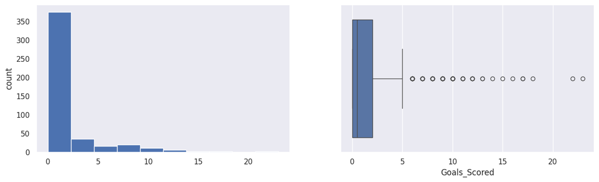

```
Assists
Skew: 2.06
```

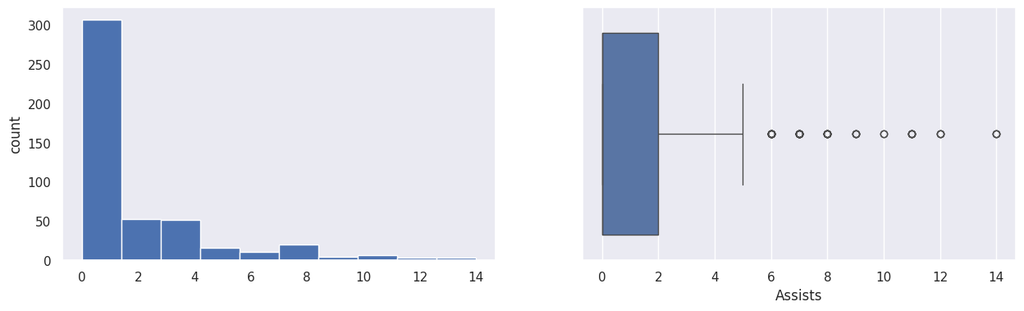

```
Total_Points
Skew: 0.75
```

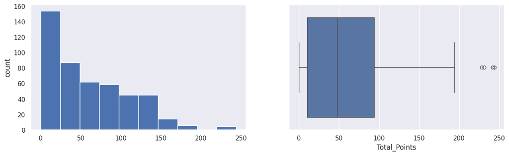

```
Minutes
Skew: 0.29
```

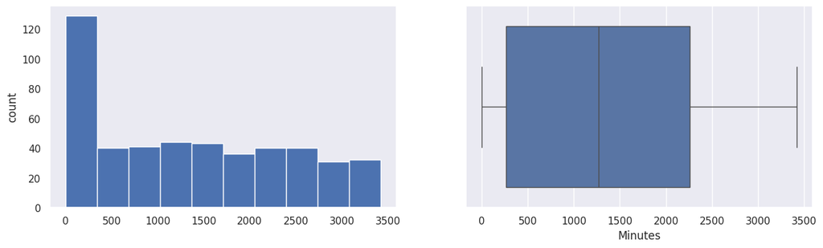

```
Goals_Conceded
Skew: 0.52
```

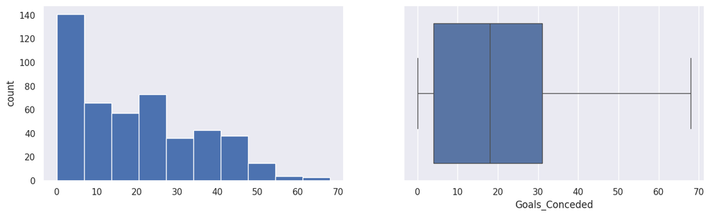

```
Creativity
Skew: 1.87
```

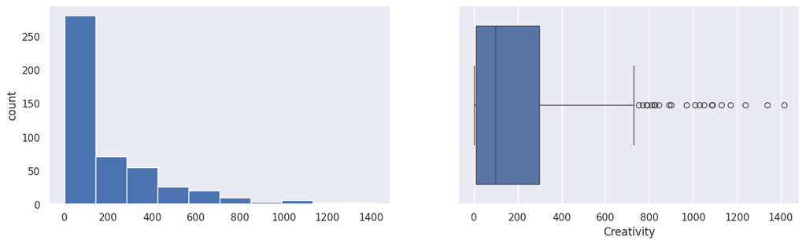

```
Influence
Skew: 0.76
```

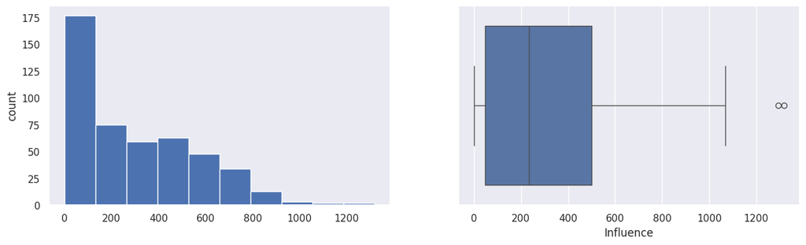

```
Threat
Skew: 2.27
```

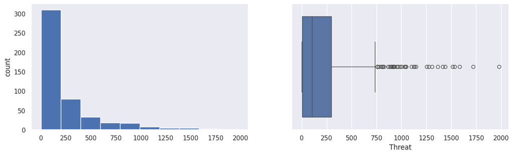

```
Bonus
Skew: 1.82
```

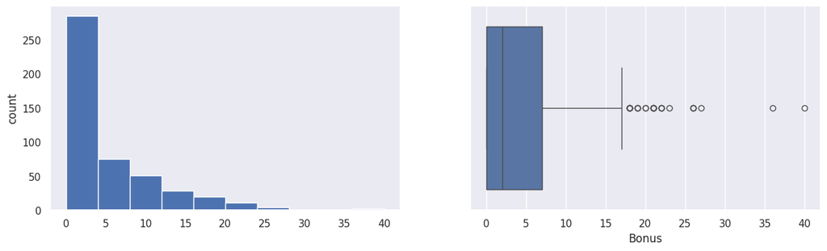

```
Clean_Sheets
Skew: 0.58
```

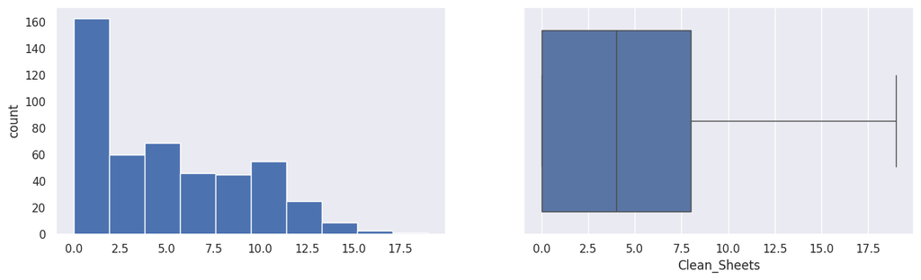

```python
#Lets check the Distribution and outliers for each numerical column in the data

for col in df.columns[3:]:
  print(col)
  print('Skew:', round(df[col].skew(), 2))

  plt.figure(figsize = (15, 4))

  plt.subplot(1, 2, 1)

  df[col].hist(bins = 10, grid = False)

  plt.ylabel('count')

  plt.subplot(1, 2, 2)

  sns.boxplot(x = df[col])

  plt.show()
```

#### **Observations:** We can see that mostly numerical variables are right skewed, which means that mostly players have lower scores in generall. It is possible to observe that most numerical columns have outliers, which might be represented by the top talented players.

```python
#Creating barplots for categorical variables:

# Function to create labeled barplots


def labeled_barplot(df, feature, perc = False, n = None):
    """
    Barplot with percentage at the top

    data: dataframe
    feature: dataframe column
    perc: whether to display percentages instead of count (default is False)
    n: displays the top n category levels (default is None, i.e., display all levels)
    """

    total = len(df[feature])  # Length of the column
    count = df[feature].nunique()
    if n is None:
        plt.figure(figsize = (count + 1, 5))
    else:
        plt.figure(figsize = (n + 1, 5))

    plt.xticks(rotation = 90, fontsize = 15)
    ax = sns.countplot(
        data = df,
        x = feature,
        palette = "viridis",
        order = df[feature].value_counts().index[:n].sort_values(),
    )

    for p in ax.patches:
        if perc == True:
            label = "{:.1f}%".format(
                100 * p.get_height() / total
            )  # Percentage of each class of the category
        else:
            label = p.get_height()  # Count of each level of the category

        x = p.get_x() + p.get_width() / 2  # Width of the plot
        y = p.get_height()  # Height of the plot

        ax.annotate(
            label,
            (x, y),
            ha = "center",
            va = "center",
            size = 12,
            xytext = (0, 5),
            textcoords = "offset points",
        )  # Annotate the percentage

    plt.show()  # Show the plot
```

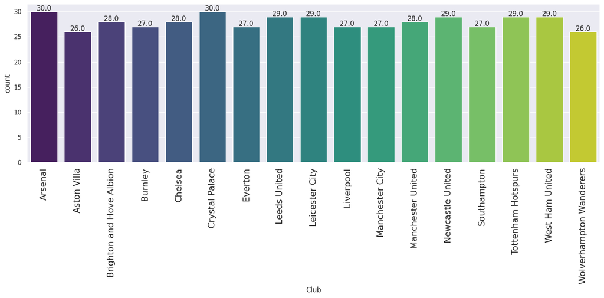

```python
#Barplot to show the count of clubs

labeled_barplot(df, 'Club')
```

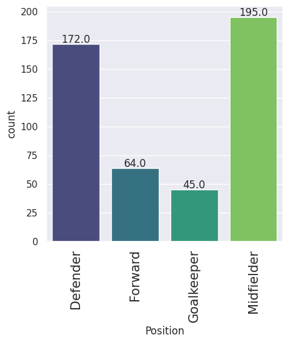

```python
#Barplot to show the count of position

labeled_barplot(df, 'Position')
```

#### **Observations:** In generall the count distribution of teams is very proportional, with Arsenal and Crystal Palace being the most frequent clubs. The most common positions are midfielders and defenders. It is reasonable that Goalkeeper is the less frequent in the dataset, since it is a specialized position.

# **Bivariate Analysis**

```python
#Lets create a correlation matrix:

df.corr(numeric_only=True)
```

|  | Goals_Scored | Assists | Total_Points | Minutes | Goals_Conceded | Creativity | Influence | Threat | Bonus | Clean_Sheets |
| --- | --- | --- | --- | --- | --- | --- | --- | --- | --- | --- |
| Goals_Scored | 1.000000 | 0.658168 | 0.696172 | 0.436865 | 0.381064 | 0.554242 | 0.597638 | 0.903802 | 0.738927 | 0.434619 |
| Assists | 0.658168 | 1.000000 | 0.701306 | 0.519280 | 0.449536 | 0.825242 | 0.591190 | 0.748933 | 0.666646 | 0.520733 |
| Total_Points | 0.696172 | 0.701306 | 1.000000 | 0.908206 | 0.801821 | 0.709679 | 0.955050 | 0.723896 | 0.867282 | 0.894135 |
| Minutes | 0.436865 | 0.519280 | 0.908206 | 1.000000 | 0.940025 | 0.613385 | 0.938259 | 0.524276 | 0.676415 | 0.917858 |
| Goals_Conceded | 0.381064 | 0.449536 | 0.801821 | 0.940025 | 1.000000 | 0.532461 | 0.861307 | 0.458876 | 0.587797 | 0.758916 |
| Creativity | 0.554242 | 0.825242 | 0.709679 | 0.613385 | 0.532461 | 1.000000 | 0.639369 | 0.659140 | 0.638027 | 0.619753 |
| Influence | 0.597638 | 0.591190 | 0.955050 | 0.938259 | 0.861307 | 0.639369 | 1.000000 | 0.613462 | 0.817605 | 0.882480 |
| Threat | 0.903802 | 0.748933 | 0.723896 | 0.524276 | 0.458876 | 0.659140 | 0.613462 | 1.000000 | 0.687508 | 0.520807 |
| Bonus | 0.738927 | 0.666646 | 0.867282 | 0.676415 | 0.587797 | 0.638027 | 0.817605 | 0.687508 | 1.000000 | 0.670131 |
| Clean_Sheets | 0.434619 | 0.520733 | 0.894135 | 0.917858 | 0.758916 | 0.619753 | 0.882480 | 0.520807 | 0.670131 | 1.000000 |

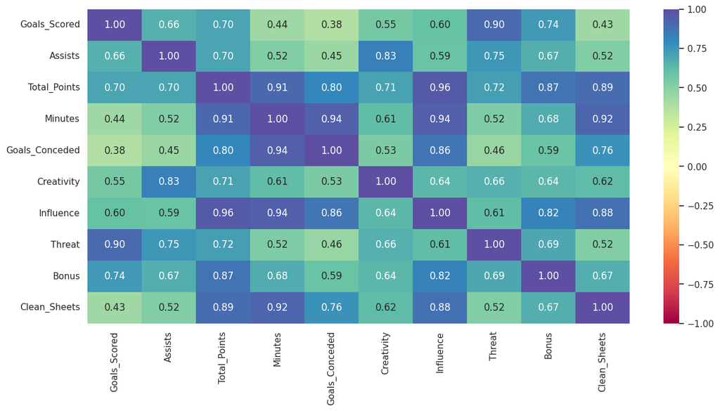

```python
#Plotting the correlation matrix

plt.figure(figsize = (15, 7))

sns.heatmap(df.corr(numeric_only=True), annot = True, vmin= -1, vmax=1, fmt = ".2f", cmap = "Spectral")

plt.show()
```

#### **Observations:** The correlations matrix above demonstrates that all the variables are positively correlated to each other at some extent. The most correlated variables can be visualized in dark blue. We can see that Goals_Scored is highly correlated with Threat, Assists is highly correlated with Creativity, Total_Points is highly correlated with Influence and Minutes.

```python
#Creating a list of numerical variables:

cols_list = df.select_dtypes(include = np.number).columns.tolist()
```

```python
cols_list
```

```
['Goals_Scored',
 'Assists',
 'Total_Points',
 'Minutes',
 'Goals_Conceded',
 'Creativity',
 'Influence',
 'Threat',
 'Bonus',
 'Clean_Sheets']
```

```python
#Checking teams who have Scored the most points

def bivariate(data, col1, col2):
    plt.figure(figsize = (15, 8))

    sns.barplot(data = data, x = col1 , y = col2 , errorbar=('ci', False), hue=col1, palette='viridis')

    plt.xticks(rotation = 90)

    plt.show()
```

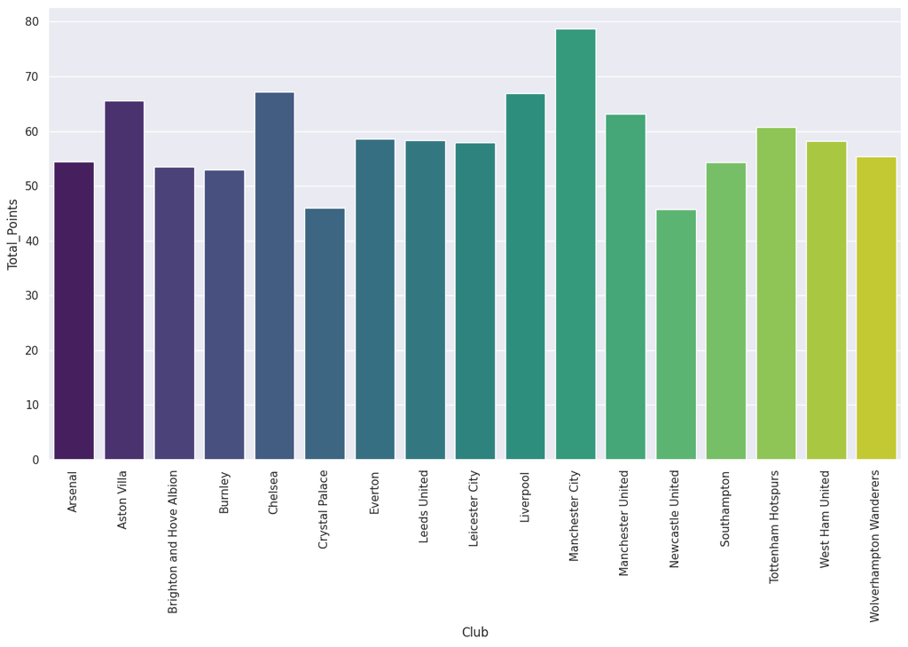

```python
bivariate(df, 'Club', 'Total_Points')
```

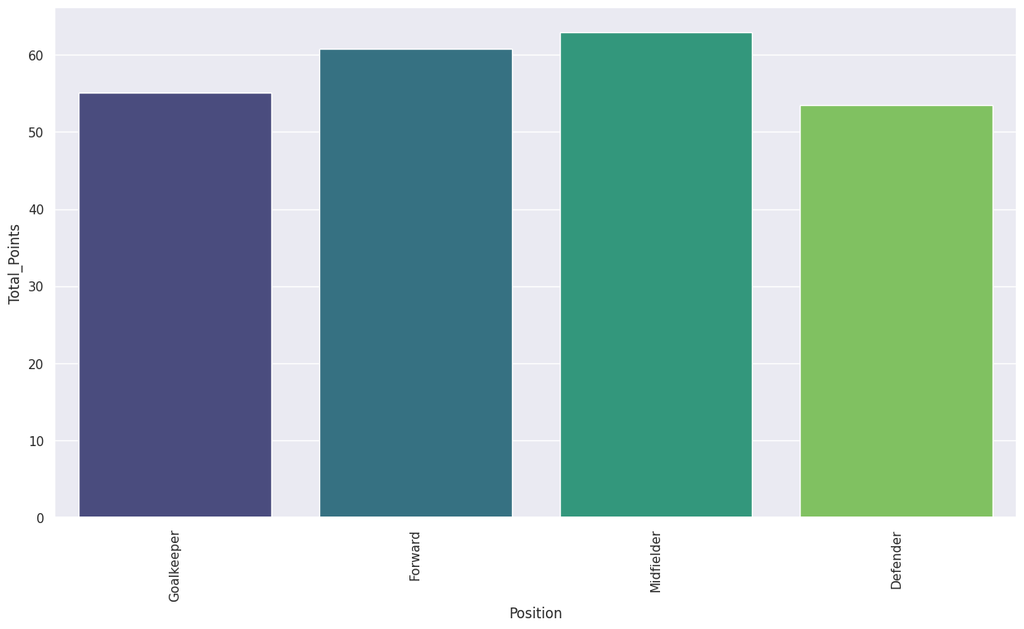

```python
 #Checking which positions tend to score more points:

bivariate(df, 'Position', 'Total_Points')
```

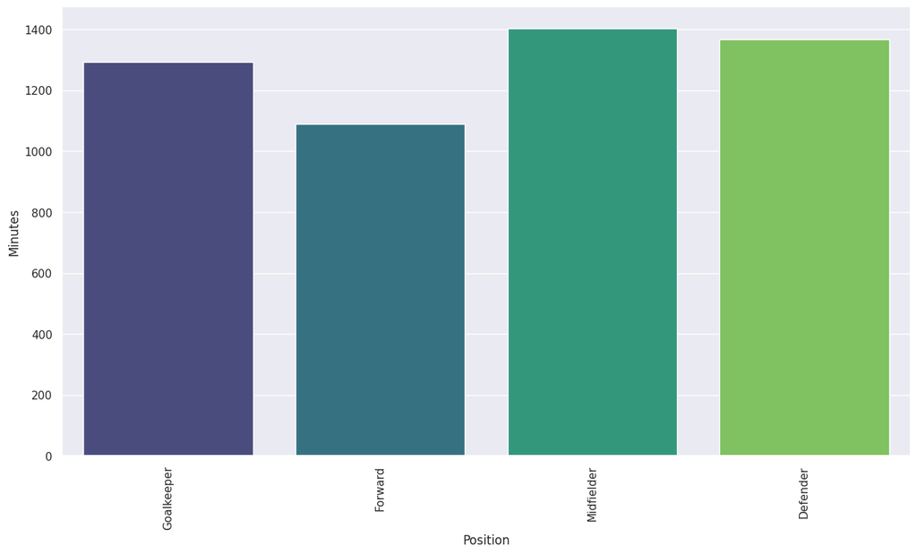

```python
#Checking the total number of minutes played, on average, across different positions.

bivariate(df, 'Position', 'Minutes')
```

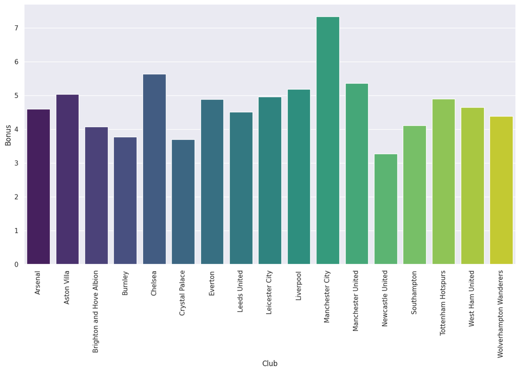

```python
#Checking the teams with most bonus points:

bivariate(df, 'Club', 'Bonus')
```

```python
#Checking for players who scored the most points last season:

unique_position = df.Position.unique().tolist()
max_points = pd.DataFrame()

for i in unique_position:
    df2 = df[df.Position == i]
    max_points = pd.concat([max_points, df2[df2.Total_Points == df2.Total_Points.max()][['Player_Name', 'Club', 'Position', 'Total_Points']]])

max_points.sort_values(by='Total_Points', ascending=False)
```

|  | Player_Name | Club | Position | Total_Points |
| --- | --- | --- | --- | --- |
| 315 | Bruno Fernandes | Manchester United | Midfielder | 244 |
| 403 | Harry Kane | Tottenham Hotspurs | Forward | 242 |
| 36 | Emiliano Martinez | Aston Villa | Goalkeeper | 186 |
| 223 | Stuart Dallas | Leeds United | Defender | 171 |

```python
#Checking for Top 10 Players in terms of Scored Points

top_10 = df.sort_values(by='Total_Points', ascending=False).head(10)

top_10.reset_index(drop=True, inplace=True)

top_10 = top_10[['Player_Name', 'Club', 'Position', 'Total_Points']]

top_10
```

|  | Player_Name | Club | Position | Total_Points |
| --- | --- | --- | --- | --- |
| 0 | Bruno Fernandes | Manchester United | Midfielder | 244 |
| 1 | Harry Kane | Tottenham Hotspurs | Forward | 242 |
| 2 | Mohamed Salah | Liverpool | Midfielder | 231 |
| 3 | Heung-Min Son | Tottenham Hotspurs | Midfielder | 228 |
| 4 | Patrick Bamford | Leeds United | Forward | 194 |
| 5 | Jamie Vardy | Leicester City | Forward | 187 |
| 6 | Emiliano Martinez | Aston Villa | Goalkeeper | 186 |
| 7 | Sadio Mane | Liverpool | Midfielder | 176 |
| 8 | Marcus Rashford | Manchester United | Midfielder | 174 |
| 9 | Stuart Dallas | Leeds United | Defender | 171 |

```
Club
```

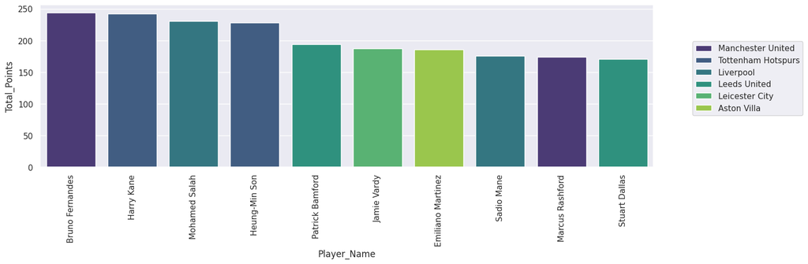

```
Position
```

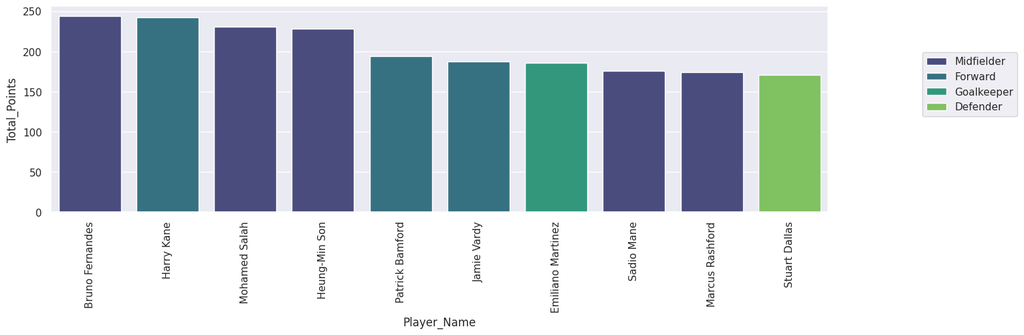

```python
#Plotting the players with most points

for col in top_10.columns[1:3]:
  print(col)

  plt.figure(figsize = (15, 4))

  sns.barplot(data = top_10, x = 'Player_Name' , y = 'Total_Points' , errorbar=('ci', False), hue=col, palette='viridis')

  plt.xticks(rotation = 90)

  plt.legend(loc='upper right', bbox_to_anchor=(1.25, 0.8))

  plt.show()
```

#### **Observations**: We can see that for the top 10 players, two of them plays for the Manchester United, two play for Liverpool, and two play for for Tottenham. The most common position for the top 10 players is Midfielder.

```python
#Library to scale the data with z-score

from sklearn.preprocessing import StandardScaler
```

```python
#Dropping non-numerical columns

df_numerical = df.drop(columns=['Player_Name', 'Club', 'Position'])

df_numerical.info()
```

```
<class 'pandas.core.frame.DataFrame'>
RangeIndex: 476 entries, 0 to 475
Data columns (total 10 columns):
 #   Column          Non-Null Count  Dtype
---  ------          --------------  -----
 0   Goals_Scored    476 non-null    int64
 1   Assists         476 non-null    int64
 2   Total_Points    476 non-null    int64
 3   Minutes         476 non-null    int64
 4   Goals_Conceded  476 non-null    int64
 5   Creativity      476 non-null    float64
 6   Influence       476 non-null    float64
 7   Threat          476 non-null    int64
 8   Bonus           476 non-null    int64
 9   Clean_Sheets    476 non-null    int64
dtypes: float64(2), int64(8)
memory usage: 37.3 KB
```

```python
#Scaling the data before clustering analysis
scaler = StandardScaler()

df_scaled = pd.DataFrame(scaler.fit_transform(df_numerical), columns=df_numerical.columns)

df_scaled.head()
```

|  | Goals_Scored | Assists | Total_Points | Minutes | Goals_Conceded | Creativity | Influence | Threat | Bonus | Clean_Sheets |
| --- | --- | --- | --- | --- | --- | --- | --- | --- | --- | --- |
| 0 | -0.552608 | -0.647555 | -1.122506 | -1.232383 | -1.202653 | -0.780115 | -1.039325 | -0.707638 | -0.755435 | -1.081123 |
| 1 | 3.213401 | 0.461208 | 1.375560 | 0.539871 | 0.115663 | 0.443542 | 1.150596 | 1.799393 | 2.606688 | 0.513521 |
| 2 | -0.552608 | -0.647555 | 1.414592 | 1.672585 | 1.120094 | -0.780115 | 1.523682 | -0.701346 | 1.005677 | 1.424747 |
| 3 | 0.895857 | 1.200384 | 1.082818 | 1.134662 | 0.743432 | 1.809706 | 0.741621 | 2.387618 | 0.525374 | 0.741328 |
| 4 | -0.552608 | 0.461208 | -0.439441 | -0.546229 | -0.574884 | -0.105790 | -0.459134 | -0.465428 | -0.275132 | -0.625510 |

```python
#Importing PCA Library

from sklearn.decomposition import PCA

# Defining the number of principal components to generate
n = df_numerical.shape[1]

# Initializing PCA with n components and setting the seed to 1
pca = PCA(n_components=n, random_state=1)

#Applying PCA on the scaled dataset
df_pca = pd.DataFrame(pca.fit_transform(df_scaled))

# The percentage of variance explained by each principal component is stored
exp_var = pca.explained_variance_ratio_
```

# **K-Means Clustering**

```python
# Library compute distances
from scipy.spatial.distance import cdist, pdist

# Library perform K-means clustering and compute silhouette scores
from sklearn.cluster import KMeans
from sklearn.metrics import silhouette_score
```

```python
k_means_df = df_pca.copy()

k_means_df.head()
```

|  | 0 | 1 | 2 | 3 | 4 | 5 | 6 | 7 | 8 | 9 |
| --- | --- | --- | --- | --- | --- | --- | --- | --- | --- | --- |
| 0 | -2.916600 | 0.569939 | -0.041871 | 0.190663 | 0.003485 | 0.008158 | -0.042314 | 0.064757 | -0.057486 | -0.006269 |
| 1 | 3.815468 | 1.999554 | -2.216345 | 0.757341 | -0.119000 | -0.541975 | -0.233941 | -0.293053 | -0.075356 | 0.238019 |
| 2 | 1.943396 | -2.757446 | -0.958238 | 0.816920 | 0.041188 | 0.376978 | 0.005235 | 0.138392 | 0.306183 | 0.136656 |
| 3 | 3.502427 | 1.043441 | 0.581995 | -0.969567 | 0.415848 | -0.358456 | 0.661746 | 0.376272 | 0.260200 | 0.155934 |
| 4 | -1.153639 | 0.422189 | 0.642307 | 0.269271 | -0.271583 | 0.405367 | -0.033575 | 0.098886 | 0.035234 | 0.034877 |

```python
#Empty dictionary to store distortions

AvgDistortion = {}
```

```python
#Iterate for a range of Ks and fit the scaled data to the algorithm
#Use inertia attribute from kmeans object and store the inertia value for that k

for k in range(1,15):

    model = KMeans(n_clusters = k, random_state = 42, n_init = "auto")

    model.fit(df_pca)

    prediction = model.predict(k_means_df)

    distortion = (
        sum(np.min(cdist(k_means_df, model.cluster_centers_, "euclidean"), axis = 1))
        / k_means_df.shape[0]
    )

    AvgDistortion[k] = distortion
```

```python
AvgDistortion
```

```
{1: 2.773037110097803,
 2: 1.8571691335599736,
 3: 1.5628794778061599,
 4: 1.3557368359611872,
 5: 1.2924554544010316,
 6: 1.2299896613141477,
 7: 1.1698205619340916,
 8: 1.121916667177523,
 9: 1.0952097153818396,
 10: 1.0321524046799253,
 11: 1.021502640797693,
 12: 0.9998153362565623,
 13: 0.9853605485319921,
 14: 0.9644597167841082}
```

[figure not shown]

```python
#Elbow Plot

plt.figure()

plt.plot(list(AvgDistortion.keys()), list(AvgDistortion.values()), 'bx-')

plt.xlabel('Number of Clusters (K)')

plt.ylabel('Average Distortion')

plt.show()
```

#### **Observations:** The Elbow plot shows that the optimal number of clusters (k) is seems to be 4 or 5. After 4 clusters, the curve starts to flatten out, indicating that adding clusters would prove no valuable returns. However, let's plot the silhouete score to make sure we decide on the optimal number of clusters.

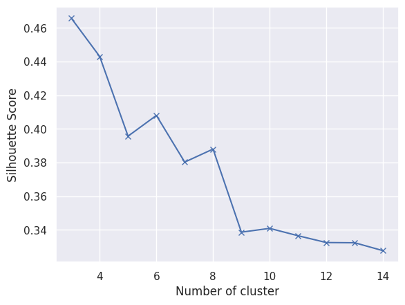

```python
# Empty dictionary to store the Silhouette score for each value of K
sc = {}

# Iterate for a range of Ks and fit the scaled data to the algorithm. Store the Silhouette score for that K
for k in range(3, 15):
    kmeans = KMeans(n_clusters = k, random_state = 42, n_init='auto').fit(df_pca)

    labels = kmeans.predict(df_pca)

    sc[k] = silhouette_score(df_pca, labels)

# Elbow plot
plt.figure()

plt.plot(list(sc.keys()), list(sc.values()), 'bx-')

plt.xlabel("Number of cluster")

plt.ylabel("Silhouette Score")

plt.show()
```

The silhouette score plot, shows that 4 clusters seems to have a better performance than 5 clusters, so let's follow with 4.

```python
#Creating a model with 4 clusters:

kmeans = KMeans(n_clusters=4, random_state = 42, n_init = "auto")

#Fitting the model to the dataset

kmeans.fit(k_means_df)
```

```
KMeans(n_clusters=4, random_state=42)
```

```python
# Creating a copy of the original data
df_copy = df.copy()

# Adding K-Means cluster labels to the K-Means dataframe
k_means_df["KM_segments"] = kmeans.labels_

# Adding K-Means cluster labels to the original dataframe
df_copy["KM_segments"] = kmeans.labels_
```

# **Cluster Profiling**

```python
df_copy.head()
```

|  | Player_Name | Club | Position | Goals_Scored | Assists | Total_Points | Minutes | Goals_Conceded | Creativity | Influence | Threat | Bonus | Clean_Sheets | KM_segments |
| --- | --- | --- | --- | --- | --- | --- | --- | --- | --- | --- | --- | --- | --- | --- |
| 0 | Alex Runnarsson | Arsenal | Goalkeeper | 0 | 0 | 1 | 15 | 0 | 0.0 | 16.6 | 0 | 0 | 0 | 0 |
| 1 | Alexandre Lacazette | Arsenal | Forward | 13 | 3 | 129 | 1916 | 21 | 307.4 | 602.4 | 797 | 21 | 7 | 3 |
| 2 | Bernd Leno | Arsenal | Goalkeeper | 0 | 0 | 131 | 3131 | 37 | 0.0 | 702.2 | 2 | 11 | 11 | 2 |
| 3 | Bukayo Saka | Arsenal | Midfielder | 5 | 5 | 114 | 2554 | 31 | 650.6 | 493.0 | 984 | 8 | 8 | 1 |
| 4 | Calum Chambers | Arsenal | Defender | 0 | 3 | 36 | 751 | 10 | 169.4 | 171.8 | 77 | 3 | 2 | 0 |

```python
#Grouping the cluster labels
km_cluster_profile = df_copy.groupby('KM_segments').mean(numeric_only = True)
```

```python
km_cluster_profile
```

| KM_segments | Goals_Scored | Assists | Total_Points | Minutes | Goals_Conceded | Creativity | Influence | Threat | Bonus | Clean_Sheets |
| --- | --- | --- | --- | --- | --- | --- | --- | --- | --- | --- |
| 0 | 0.354331 | 0.425197 | 18.795276 | 479.161417 | 7.377953 | 54.072047 | 86.100000 | 60.862205 | 0.917323 | 1.417323 |
| 1 | 3.947368 | 3.973684 | 92.394737 | 1882.434211 | 26.881579 | 424.852632 | 414.552632 | 450.881579 | 8.131579 | 6.697368 |
| 2 | 0.990385 | 0.932692 | 91.980769 | 2492.403846 | 35.365385 | 179.858654 | 540.030769 | 157.076923 | 6.384615 | 9.182692 |
| 3 | 9.880952 | 7.785714 | 154.571429 | 2675.880952 | 36.285714 | 679.909524 | 730.938095 | 976.666667 | 17.404762 | 10.357143 |

```python
# Creating the "count_in_each_segment" variable in K-Means cluster profile

km_cluster_profile["count_in_each_segment"] = (
    df_copy.groupby('KM_segments')["Total_Points"].count().values)
```

```python
km_cluster_profile
```

| KM_segments | Goals_Scored | Assists | Total_Points | Minutes | Goals_Conceded | Creativity | Influence | Threat | Bonus | Clean_Sheets | count_in_each_segment |
| --- | --- | --- | --- | --- | --- | --- | --- | --- | --- | --- | --- |
| 0 | 0.354331 | 0.425197 | 18.795276 | 479.161417 | 7.377953 | 54.072047 | 86.100000 | 60.862205 | 0.917323 | 1.417323 | 254 |
| 1 | 3.947368 | 3.973684 | 92.394737 | 1882.434211 | 26.881579 | 424.852632 | 414.552632 | 450.881579 | 8.131579 | 6.697368 | 76 |
| 2 | 0.990385 | 0.932692 | 91.980769 | 2492.403846 | 35.365385 | 179.858654 | 540.030769 | 157.076923 | 6.384615 | 9.182692 | 104 |
| 3 | 9.880952 | 7.785714 | 154.571429 | 2675.880952 | 36.285714 | 679.909524 | 730.938095 | 976.666667 | 17.404762 | 10.357143 | 42 |

```python
# Highlight the maximum average value among all the clusters for each of the variables
km_cluster_profile.style.highlight_max(color = 'lightblue', axis = 0)
```

| KM_segments | Goals_Scored | Assists | Total_Points | Minutes | Goals_Conceded | Creativity | Influence | Threat | Bonus | Clean_Sheets | count_in_each_segment |
| --- | --- | --- | --- | --- | --- | --- | --- | --- | --- | --- | --- |
| 0 | 0.354331 | 0.425197 | 18.795276 | 479.161417 | 7.377953 | 54.072047 | 86.100000 | 60.862205 | 0.917323 | 1.417323 | 254 |
| 1 | 3.947368 | 3.973684 | 92.394737 | 1882.434211 | 26.881579 | 424.852632 | 414.552632 | 450.881579 | 8.131579 | 6.697368 | 76 |
| 2 | 0.990385 | 0.932692 | 91.980769 | 2492.403846 | 35.365385 | 179.858654 | 540.030769 | 157.076923 | 6.384615 | 9.182692 | 104 |
| 3 | 9.880952 | 7.785714 | 154.571429 | 2675.880952 | 36.285714 | 679.909524 | 730.938095 | 976.666667 | 17.404762 | 10.357143 | 42 |

```python
# Printing the players in each cluster:

for cl in df_copy['KM_segments'].unique():
    print("CLUSTER {},:".format(cl))
    print(df_copy[df_copy['KM_segments'] == cl]["Player_Name"].unique())
    print()
```

```
CLUSTER 0,:
['Alex Runnarsson' 'Calum Chambers' 'Cedric Soares' 'David Luiz'
 'Edward Nketiah' 'Gabriel Teodoro Martinelli Silva' 'Martin Odegaard'
 'Matt Macey' 'Miguel Azeez' 'Mohamed Naser El Sayed Elneny' 'Pablo Mari'
 'Reiss Nelson' 'Sead Kolasinac' 'Shkodran Mustafi'
 'Sokratis Papastathopoulos' 'Thomas Partey' 'William Saliba'
 'Ahmed El Mohamady' 'Carney Chukwuemeka' 'Conor Hourihane'
 'Henri Lansbury' 'Jacob Ramsey' 'Jaden Philogene-Bidace'
 'Jose Peleteiro Romallo' 'Keinan Davis' 'Kortney Hause'
 'Mahmoud Ahmed Ibrahim Hassan' 'Marvelous Nakamba' 'Morgan Sanson'
 'Orjan Nyland' 'Wesley Moraes' 'Aaron Connolly' 'Alexis Mac Allister'
 'Alireza Jahanbakhsh' 'Andi Zeqiri' 'Bernardo Fernandes da Silva Junior'
 'Davy Propper' 'Jakub Moder' 'Jason Steele' 'Jayson Molumby'
 'Jose Izquierdo' 'Mathew Ryan' 'Percy Tau' 'Reda Khadra' 'Steven Alzate'
 'Tariq Lamptey' 'Anthony Driscoll-Glennon' 'Bailey Peacock-Farrell'
 'Dale Stephens' 'Erik Pieters' 'Jack Cork' 'Jay Rodriguez'
 'Jeff Hendrick' 'Jimmy Dunne' 'Joel Mumbongo' 'Johann Berg Gudmundsson'
 'Josh Benson' 'Kevin Long' 'Lewis Richardson' 'Phil Bardsley'
 'Robbie Brady' 'Will Norris' 'Billy Gilmour'
 'Emerson Palmieri dos Santos' 'Faustino Anjorin' 'Fikayo Tomori'
 'Karlo Ziger' 'Kepa Arrizabalaga' 'Marcos Alonso' 'Olivier Giroud'
 'Valentino Livramento' 'Willy Caballero' 'Connor Wickham' 'Jack Butland'
 'James McArthur' 'James McCarthy' 'James Tomkins' 'Jean-Philippe Mateta'
 'Mamadou Sakho' 'Martin Kelly' 'Michy Batshuayi' 'Nathan Ferguson'
 'Nathaniel Clyne' 'Reece Hannam' 'Ryan Inniss' 'Sam Woods' 'Scott Dann'
 'Stephen Henderson' 'Andre Tavares Gomes' 'Anthony Gordon'
 'Bernard Caldeira Duarte' 'Cenk Tosun' 'Fabian Delph' 'Joao Virginia'
 'Jonjoe Kenny' 'Joshua King' 'Moise Kean' 'Nathan Broadhead'
 'Niels Nkounkou' 'Robin Olsen' 'Tom Davies' 'Adam Forshaw'
 'Diego Llorente' 'Francisco Casilla' 'Gaetano Berardi'
 'Ian Carlo Poveda-Ocampo' 'Jack Jenkins' 'Jamie Shackleton'
 'Jay-Roy Grot' 'Jordan Stevens' 'Kamil Miazek' 'Leif Davis'
 'Mateusz Bogusz' 'Niall Huggins' 'Pablo Hernandez' 'Robin Koch'
 'Tyler Roberts' 'Cengiz Under' 'Christian Fuchs' 'Daniel Amartey'
 'Demarai Gray' 'Dennis Praet' 'Filip Benkovic' 'Hamza Choudhury'
 'Islam Slimani' 'Luke Thomas' 'Nampalys Mendy'
 'Ricardo Domingos Barbosa Pereira' 'Sidnei Tavares' 'Thakgalo Leshabela'
 'Vontae Daley-Campbell' 'Wes Morgan' 'Adrian Castillo'
 'Alex Oxlade-Chamberlain' 'Caoimhin Kelleher' 'Curtis Jones'
 'Dean Henderson' 'Divock Origi' 'James Milner' 'Joel Matip'
```

[output cut: 80 more lines]

```
 'Matej Vydra' 'Benjamin Chilwell' 'Callum Hudson-Odoi'
 'Christian Pulisic' 'Hakim Ziyech' 'Jorge Luiz Frello Filho'
 'Kai Havertz' 'Reece James' 'Tammy Abraham' 'Andros Townsend'
 'Christian Benteke' 'Eberechi Eze' 'Jeffrey Schlupp' 'Jordan Ayew'
 'Alex Iwobi' 'Gylfi Sigurdsson' 'James Rodriguez' 'Lucas Digne'
 'Helder Costa' 'Mateusz Klich' 'Rodrigo Moreno' 'Ayoze Perez'
 'Harvey Barnes' 'Kelechi Iheanacho' 'Marc Albrighton' 'Timothy Castagne'
 'Diogo Jota' 'Bernardo Silva' 'Ferran Torres' 'Joao Cancelo'
 'Anthony Martial' 'Edinson Cavani' 'Luke Shaw' 'Mason Greenwood'
 'Paul Pogba' 'Allan Saint-Maximin' 'Jacob Murphy' 'Joelinton de Lira'
 'Joseph Willock' 'Matt Ritchie' 'Miguel Almiron' 'Nathan Redmond'
 'Stuart Armstrong' 'Theo Walcott' 'Gareth Bale' 'Lucas Moura'
 'Serge Aurier' 'Sergio Reguilon' 'Tanguy Ndombele' 'Jesse Lingard'
 'Pablo Fornals' 'Said Benrahma' 'Vladimir Coufal' 'Adama Traore'
 'Daniel Castelo Podence' 'Fabio Silva' 'Ruben Neves']
```

```python
df_copy.groupby(["KM_segments", "Club"])['Player_Name'].count()
```

| KM_segments | Club | Player_Name |
| --- | --- | --- |
| 0 | Arsenal | 17 |
|  | Aston Villa | 14 |
|  | Brighton and Hove Albion | 15 |
|  | Burnley | 16 |
|  | Chelsea | 10 |
|  | Crystal Palace | 16 |
|  | Everton | 13 |
|  | Leeds United | 16 |
|  | Leicester City | 15 |
|  | Liverpool | 16 |
|  | Manchester City | 12 |
|  | Manchester United | 15 |
|  | Newcastle United | 16 |
|  | Southampton | 14 |
|  | Tottenham Hotspurs | 18 |
|  | West Ham United | 17 |
|  | Wolverhampton Wanderers | 14 |
| 1 | Arsenal | 8 |
|  | Aston Villa | 3 |
|  | Brighton and Hove Albion | 5 |
|  | Burnley | 4 |
|  | Chelsea | 8 |
|  | Crystal Palace | 5 |
|  | Everton | 4 |
|  | Leeds United | 3 |
|  | Leicester City | 5 |
|  | Liverpool | 1 |
|  | Manchester City | 3 |
|  | Manchester United | 5 |
|  | Newcastle United | 6 |
|  | Southampton | 3 |
|  | Tottenham Hotspurs | 5 |
|  | West Ham United | 4 |
|  | Wolverhampton Wanderers | 4 |
| 2 | Arsenal | 4 |
|  | Aston Villa | 6 |
|  | Brighton and Hove Albion | 7 |
|  | Burnley | 6 |
|  | Chelsea | 8 |
|  | Crystal Palace | 8 |
|  | Everton | 8 |
|  | Leeds United | 6 |
|  | Leicester City | 6 |
|  | Liverpool | 5 |
|  | Manchester City | 6 |
|  | Manchester United | 6 |
|  | Newcastle United | 6 |
|  | Southampton | 7 |
|  | Tottenham Hotspurs | 4 |
|  | West Ham United | 4 |
|  | Wolverhampton Wanderers | 7 |
| 3 | Arsenal | 1 |
|  | Aston Villa | 3 |
|  | Brighton and Hove Albion | 1 |
|  | Burnley | 1 |
|  | Chelsea | 2 |
|  | Crystal Palace | 1 |
|  | Everton | 2 |
|  | Leeds United | 4 |
|  | Leicester City | 3 |
|  | Liverpool | 5 |
|  | Manchester City | 6 |
|  | Manchester United | 2 |
|  | Newcastle United | 1 |
|  | Southampton | 3 |
|  | Tottenham Hotspurs | 2 |
|  | West Ham United | 4 |
|  | Wolverhampton Wanderers | 1 |

**dtype:** int64

```python
df_copy.head()
```

|  | Player_Name | Club | Position | Goals_Scored | Assists | Total_Points | Minutes | Goals_Conceded | Creativity | Influence | Threat | Bonus | Clean_Sheets | KM_segments |
| --- | --- | --- | --- | --- | --- | --- | --- | --- | --- | --- | --- | --- | --- | --- |
| 0 | Alex Runnarsson | Arsenal | Goalkeeper | 0 | 0 | 1 | 15 | 0 | 0.0 | 16.6 | 0 | 0 | 0 | 0 |
| 1 | Alexandre Lacazette | Arsenal | Forward | 13 | 3 | 129 | 1916 | 21 | 307.4 | 602.4 | 797 | 21 | 7 | 3 |
| 2 | Bernd Leno | Arsenal | Goalkeeper | 0 | 0 | 131 | 3131 | 37 | 0.0 | 702.2 | 2 | 11 | 11 | 2 |
| 3 | Bukayo Saka | Arsenal | Midfielder | 5 | 5 | 114 | 2554 | 31 | 650.6 | 493.0 | 984 | 8 | 8 | 1 |
| 4 | Calum Chambers | Arsenal | Defender | 0 | 3 | 36 | 751 | 10 | 169.4 | 171.8 | 77 | 3 | 2 | 0 |

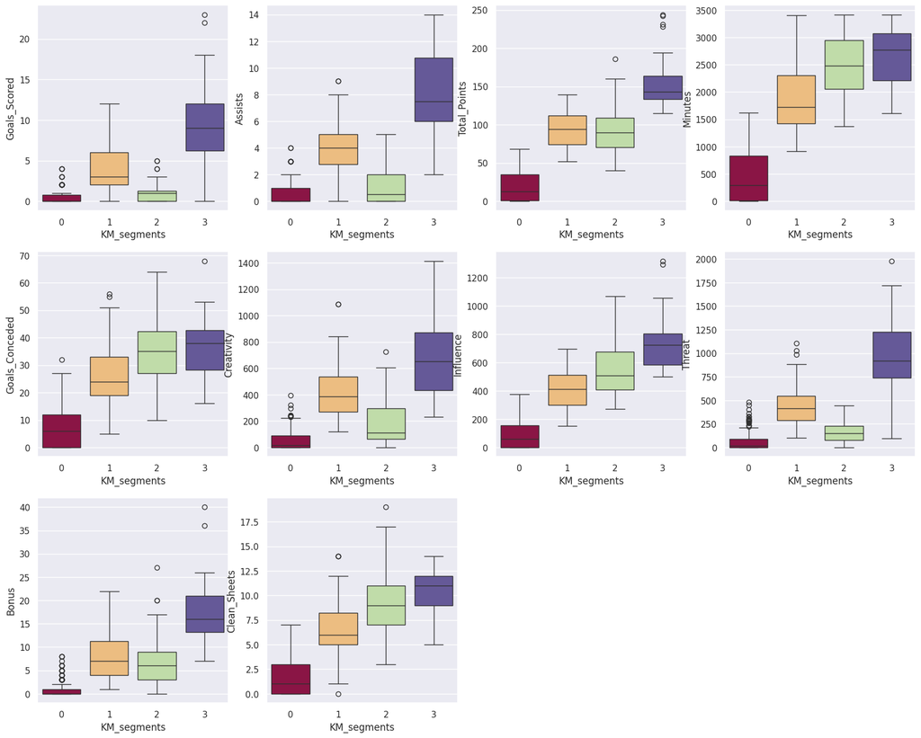

```python
num_cols = ['Goals_Scored', 'Assists', 'Total_Points', 'Minutes', 'Goals_Conceded', 'Creativity', 'Influence', 'Threat', 'Bonus', 'Clean_Sheets']

plt.figure(figsize=(20, 16))

for i, variable in enumerate(num_cols):
  plt.subplot(3, 4, i+1)
  sns.boxplot(x='KM_segments', y=variable, data=df_copy, hue='KM_segments', legend=None, palette='Spectral')
plt.show()
```

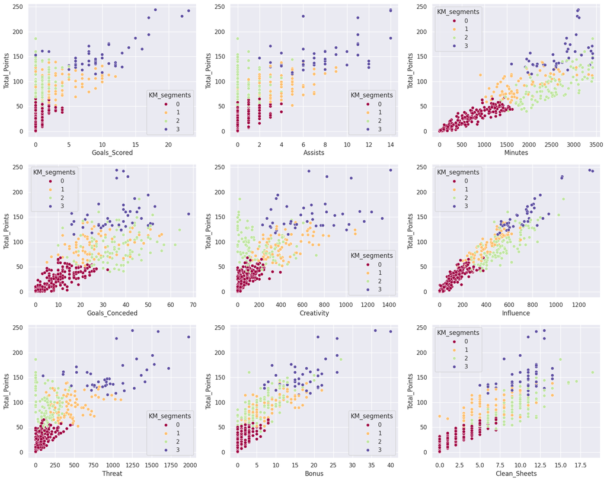

```python
cols = ['Goals_Scored', 'Assists', 'Minutes', 'Goals_Conceded', 'Creativity', 'Influence', 'Threat', 'Bonus', 'Clean_Sheets']

plt.figure(figsize=(20, 16))

for i, variable in enumerate(cols):
  plt.subplot(3, 3, i+1)
  sns.scatterplot(x=variable, y='Total_Points', data=df_copy, hue='KM_segments', palette='Spectral')
plt.show()
```

```python
df_copy.groupby(["KM_segments"])['Player_Name'].count()
```

| KM_segments | Player_Name |
| --- | --- |
| 0 | 254 |
| 1 | 76 |
| 2 | 104 |
| 3 | 42 |

**dtype:** int64

# **Conclusions about each cluster**

- **Cluster 0**: There are 254 players on cluster 0. The players on this group appears to be low performers when comparing to the other players and do not present impressive scores on the performance metrics.
- **Cluster 1**: There are 76 players on this cluster. When compared to players in cluster 2, these players seem to have better performance in terms of Goals_Scored, Assists, and Threat.
- **Cluster 2**: There are 104 players in cluster 2. This group of players seems to be composed of average players, but stands out in terms of minutes played, Influence, and clean sheets. It also has a great amount of goals conceded, which suggests a problem in performance.
- **Cluster 3**: There are 42 players on cluster 3. These players definetely appear to be the top performers in the dataset and are the players that should be considered for a higher price. This cluster stands out from all the other clusters in terms of performance and has the highest scores for key performance variables such as Total_Points, Goals Scored, Bonus, Threat, Influence, and Creativity.

# **Model Performance**

```python
# Initializing K-Means
kmeans = KMeans(n_clusters = 4, random_state = 42, n_init = 'auto')

# Fitting and predicting K-Means on df_pca
predict = kmeans.fit_predict((df_pca))

# Calculating the silhouette score
score = silhouette_score(df_pca, predict)

print('Silhouette Score:', score)
```

```
Silhouette Score: 0.4430152162896188
```

# **Conlusion:**

The silhouette score is used to assess clustering model performance. The K-Means algorithm presented a silhouette score of 0.44, which indicates that this model did a good job in grouping the data points to appropriate clusters.